# Species data

Patrícia Singh

2025-09-24

# Tutorial 1: Retrieving Species Data from GBIF

### Learning Objectives

By the end of this tutorial, you will be able to: - Distinguish between GBIF occurrences and observations - Search and download species data from GBIF - Create basic distribution maps - Set up GBIF credentials for bulk downloads - Understand data quality considerations for SDM

## 1.1 Setup and Configuration

We will use the package `rgbif` to search and retrieve data from GBIF. Remember that we can install new packages with the function `install.packages()`.

```r
library(rgbif)
library(dplyr)
```

## 1.2 Understanding GBIF Data Types

### Occurrences vs. Observations

It is important to know the difference between occurrences and observations.

**Occurrences** include all types of biodiversity records: - Museum specimens - Fossil records  
- Human or machine observations - Environmental DNA records

Total number of all occurrences in GBIF:

```r
occ_count()
```

```
## [1] 3509428885
```

**Observations** are specifically recorded in the field by person, sensor or camera trap: - iNaturalist photo records - Birdwatchers’ checklists  
- Vegetation plot surveys

Total number of observations in GBIF:

```r
occ_count(basisOfRecord='OBSERVATION')
```

```
## [1] 16762618
```

> **💡 Tip**: For Species Distribution Modeling, observations are used because they represent recent, verified sightings rather than historical museum records.

### Country-level Data Exploration

Number of occurrences by country (check https://countrycode.org/ for country codes):

```r
occ_count(country='CZ') # Czech Republic
```

```
## [1] 5514751
```

```r
occ_count(country='SK') # Slovakia
```

```
## [1] 2119351
```

Number of observations by country:

```r
occ_count(country='CZ',basisOfRecord='OBSERVATION')
```

```
## [1] 50
```

```r
occ_count(country='SK',basisOfRecord='OBSERVATION')
```

```
## [1] 10
```

### 🧪 Try It Yourself

Change the country codes to compare data availability for your study region. Try ‘US’, ‘CA’, ‘GB’, or any other countries relevant to your research.

## 1.3 Species Selection and Validation

For this example, I picked the **Rusty Bog-moss** (*Sphagnum fuscum*), a typical bog bryophyte species. Its conservation status is Least Concern ([IUCN Red List](https://www.iucnredlist.org/species/87567639/87841272)).

### Check for Synonyms

Always verify the accepted scientific name and check for synonyms:

```r
name_suggest(q='Sphagnum fuscum', rank='species')
```

```
## Records returned [1]
## No. unique hierarchies [0]
## Args [q=Sphagnum fuscum, limit=100, rank=species, fields1=key,
##      fields2=canonicalName, fields3=rank]
## # A tibble: 1 × 3
##       key canonicalName   rank
##     <int> <chr>           <chr>
## 1 2669215 Sphagnum fuscum SPECIES
```

> **⚠️ Important**: Always check for synonyms before downloading data to ensure you’re getting all relevant records for your species.

## 1.4 Small-scale Data Retrieval

### Understanding occ_search Parameters

```r
?occ_search
```

### Search for Human Observations

For SDM studies, we typically want human observations with coordinates:

```r
occ_search(scientificName = "Sphagnum fuscum",
           hasCoordinate = TRUE,
           basisOfRecord = 'HUMAN_OBSERVATION',
           limit = 10)
```

```
## Records found [14098]
## Records returned [10]
## No. unique hierarchies [1]
## No. media records [10]
## No. facets [0]
## Args [hasCoordinate=TRUE, occurrenceStatus=PRESENT, limit=10, offset=0,
##      scientificName=Sphagnum fuscum, basisOfRecord=HUMAN_OBSERVATION,
##      fields=all]
## # A tibble: 10 × 112
##    key        scientificName  decimalLatitude decimalLongitude issues datasetKey
##    <chr>      <chr>                     <dbl>            <dbl> <chr>  <chr>
##  1 5063635624 Sphagnum fuscu…            44.2           -68.2  "cdc,… 50c9509d-…
##  2 5070966332 Sphagnum fuscu…            60.8            24.4  "cdc"  df12ca07-…
##  3 5084040147 Sphagnum fuscu…            59.7            10.8  "cdc,… b124e1e0-…
##  4 5098983252 Sphagnum fuscu…            59.8            16.0  ""     38b4c89f-…
##  5 5104647220 Sphagnum fuscu…            47.7           -91.4  "cdc,… 50c9509d-…
##  6 5107477823 Sphagnum fuscu…            59.7            10.8  "cdc,… b124e1e0-…
##  7 5107508700 Sphagnum fuscu…            59.7            10.8  "cdc,… b124e1e0-…
##  8 5108199072 Sphagnum fuscu…            46.8            12.1  "cdc,… 50c9509d-…
##  9 5108615886 Sphagnum fuscu…            56.0             9.44 "cdc,… 963a6b96-…
## 10 5108617650 Sphagnum fuscu…            56.0             9.44 "cdc,… 963a6b96-…
## # ℹ 106 more variables: publishingOrgKey <chr>, installationKey <chr>,
## #   hostingOrganizationKey <chr>, publishingCountry <chr>, protocol <chr>,
## #   lastCrawled <chr>, lastParsed <chr>, crawlId <int>, projectId <chr>,
## #   basisOfRecord <chr>, occurrenceStatus <chr>, taxonKey <int>,
## #   kingdomKey <int>, phylumKey <int>, classKey <int>, orderKey <int>,
## #   familyKey <int>, genusKey <int>, speciesKey <int>, acceptedTaxonKey <int>,
## #   acceptedScientificName <chr>, kingdom <chr>, phylum <chr>, order <chr>, …
```

> **⚠️ Important**: The `occ_search()` function has a 100,000 record limit. For larger datasets, use `occ_download()` as shown below.

One of the most interesting items from the output is “Records found” at the very top. If GBIF contains more than 100,000 records for your search, you’ll need to either: - Set additional filters (time period, geographic extent) - Split the area into spatial tiles - Use the `occ_download()` function

## 1.5 Large-scale Data Downloads

### Get Species Taxon Key

```r
key <- name_backbone(name = "Sphagnum fuscum")$usageKey
key
```

```
## [1] 2669215
```

### Setting Up GBIF Credentials

**Step 1: Find your home directory**

```r
path.expand("~")
```

```
## [1] "C:/Users/patricia/Documents"
```

**Step 2: Create .Renviron file**

In your home directory, create a plain text file called `.Renviron` (notice the leading dot) containing:

```
GBIF_USER=your_gbif_username
GBIF_PWD=your_gbif_password
GBIF_EMAIL=your_email@domain.com
```

> **🔧 Technical Note**: No quotes, no commas, one variable per line. Restart R/RStudio after creating this file.

**Step 3: Verify credentials**

```r
Sys.getenv("GBIF_USER")
```

```
## [1] "patriciasingh"
```

```r
Sys.getenv("GBIF_EMAIL")
```

```
## [1] "patadurcanova@gmail.com"
```

> **⚠️ Troubleshooting**: If these show empty results (““), your file might be named `.Renviron.txt`. Follow the instructions in the troubleshooting section below.

### Download Large Dataset

```r
# Create download request
req <- occ_download(
  pred("taxonKey", key),
  pred("hasCoordinate", TRUE),
  pred("basisOfRecord", "HUMAN_OBSERVATION"),
  format = "SIMPLE_CSV"
)

# Wait for download to complete
occ_download_wait(req, status_ping = 10)

# Download the file
zip_path <- occ_download_get(req, overwrite = TRUE,
                             curlopts = list(timeout = 600, connecttimeout = 120))

# Save a copy for future use
dir.create("data", showWarnings = FALSE)
file.copy(zip_path, "data/gbif_download.zip", overwrite = TRUE)
```

> **💡 Tip**: Large downloads can take several minutes to hours depending on the dataset size. The download runs on GBIF servers, so you can close R and check back later.

## 1.6 Data Processing

### Import Downloaded Data

```r
# Import downloaded data
if (file.exists("data/gbif_download.zip")) {
  # Extract and read the CSV file from zip
  temp_dir <- tempdir()
  unzip("data/gbif_download.zip", exdir = temp_dir)
  csv_files <- list.files(temp_dir, pattern = "\\.csv$", full.names = TRUE)
  dat <- read.delim(csv_files[1], sep = "\t", quote = "")
} else {
  # If no downloaded file exists, use occ_search for demonstration
  message("No download file found, please run the download section first")
  search_result <- occ_search(scientificName = "Sphagnum fuscum",
                              hasCoordinate = TRUE,
                              basisOfRecord = 'HUMAN_OBSERVATION',
                              limit = 300)
  dat <- search_result$data
}
```

### Check Data Quality

```r
# Check number of records
nrow(dat)
```

[output not shown]

```r
# Preview data structure
str(dat)
```

[output not shown]

```r
# Check coordinate completeness
sum(is.na(dat$decimalLatitude))
```

[output not shown]

```r
sum(is.na(dat$decimalLongitude))
```

[output not shown]

```r
# Extract the main data
gbif_Sphfuscum <- dat
```

[output not shown]

```r
head(gbif_Sphfuscum)
```

[output not shown]

### ❓ Quick Check

- How many records did you download?
- Are there any missing coordinates?
- What time period do the observations cover?

## 1.7 Basic Mapping

### Load Mapping Libraries

```r
library(maps)
```

### Create World Map

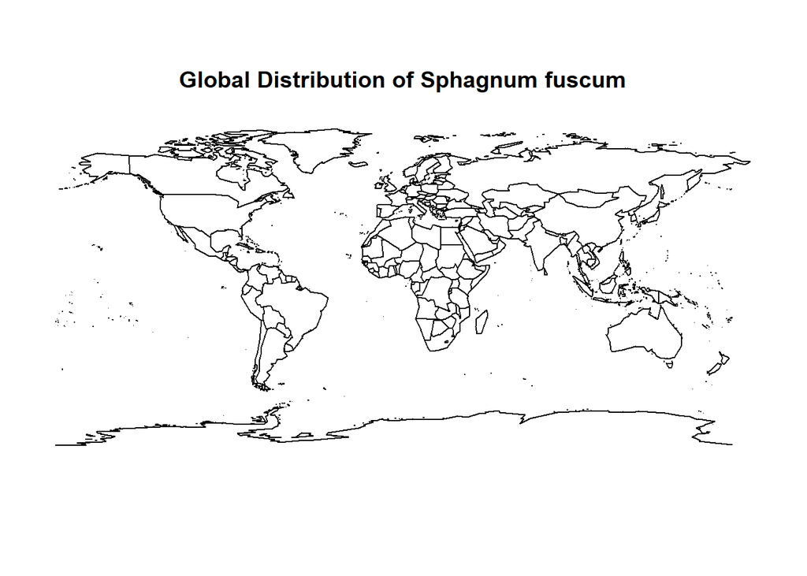

```r
map("world")
title("Global Distribution of Sphagnum fuscum")
```

### Create Regional Map (Europe)

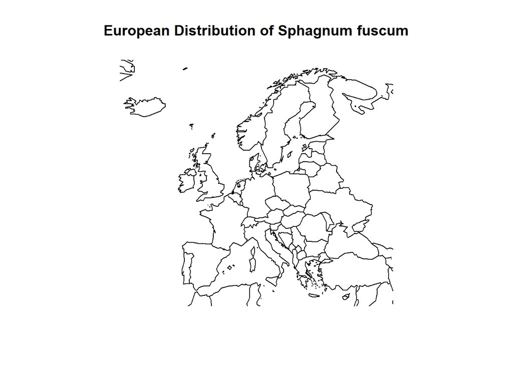

```r
maps::map('world', xlim = c(-25, 45), ylim = c(34, 72))
title("European Distribution of Sphagnum fuscum")
```

### Add Species Points

```r
points(gbif_Sphfuscum$decimalLongitude,
       gbif_Sphfuscum$decimalLatitude,
       col = 'red',
       pch = 19,
       cex = 0.5)
```

[output not shown]

[output not shown]

## Common Issues and Solutions

### .Renviron File Problems

If `Sys.getenv()` shows empty results:

1. **Show file extensions in Windows:**
   - File Explorer → View → Show → File name extensions
2. **Rename the file:**
   - Right-click `.Renviron.txt` → Rename → Remove `.txt`
   - Confirm when Windows warns about changing extensions
3. **Restart R/RStudio** after making changes

### Download Issues

- **Timeout errors**: Increase `timeout` values in `options()`
- **Too many records**: Add geographic filters using `pred("country", "US")` or coordinate bounds
- **Server busy**: Try downloading during off-peak hours

### Data Quality Issues

- **Suspicious coordinates**: Check for points at 0,0 or on country centroids
- **Old records**: Filter by year if you need recent data only
- **Duplicate records**: Remove duplicates based on coordinates and date

## Next Steps

Now that you have successfully downloaded and mapped species occurrence data, you’re ready for:

**Tutorial 2: Data Cleaning and Quality Assessment** - Removing duplicate records - Identifying spatial outliers - Temporal filtering - Coordinate validation

**Tutorial 3: Environmental Data Acquisition** - Downloading WorldClim data - Extracting environmental variables - Handling multi-temporal data

**Tutorial 4: Species Distribution Modeling** - Model selection (MaxEnt, Random Forest, etc.) - Cross-validation strategies - Model evaluation metrics

### 🧪 Final Challenge

Try downloading data for a different species in your region of interest. Consider: - A species with fewer records (< 1000) - A species with global distribution - An invasive species with recent spread

How do the patterns differ? What challenges might arise for SDM with each type?

> **📚 Additional Resources:** - [GBIF Data Quality Requirements](https://www.gbif.org/data-quality-requirements) - [rgbif Package Documentation](https://docs.ropensci.org/rgbif/) - [Species Distribution Modeling Best Practices](https://onlinelibrary.wiley.com/doi/abs/10.1111/ecog.01132)